# Dada2_report

Ramón Gallego

1/9/2018

## Dada2 report

You have successfully split your libraries into a pair (or two) of fastq files per sample. Now let’s import the output of demultiplex_both_fastq.sh

First load the packages. And let’s update the parameters we need

```
##   [1] "barcodes.fasta"           "filtered"
##   [3] "Lib_A_ACACAC_Fwd.1.fastq" "Lib_A_ACACAC_Fwd.2.fastq"
##   [5] "Lib_A_ACACAC_Rev.1.fastq" "Lib_A_ACACAC_Rev.2.fastq"
##   [7] "Lib_A_ACAGCA_Fwd.1.fastq" "Lib_A_ACAGCA_Fwd.2.fastq"
##   [9] "Lib_A_ACAGCA_Rev.1.fastq" "Lib_A_ACAGCA_Rev.2.fastq"
##  [11] "Lib_A_ACATGT_Fwd.1.fastq" "Lib_A_ACATGT_Fwd.2.fastq"
##  [13] "Lib_A_ACATGT_Rev.1.fastq" "Lib_A_ACATGT_Rev.2.fastq"
##  [15] "Lib_A_ACGACG_Fwd.1.fastq" "Lib_A_ACGACG_Fwd.2.fastq"
##  [17] "Lib_A_ACGACG_Rev.1.fastq" "Lib_A_ACGACG_Rev.2.fastq"
##  [19] "Lib_A_ATATCG_Fwd.1.fastq" "Lib_A_ATATCG_Fwd.2.fastq"
##  [21] "Lib_A_ATATCG_Rev.1.fastq" "Lib_A_ATATCG_Rev.2.fastq"
##  [23] "Lib_A_ATCAGT_Fwd.1.fastq" "Lib_A_ATCAGT_Fwd.2.fastq"
##  [25] "Lib_A_ATCAGT_Rev.1.fastq" "Lib_A_ATCAGT_Rev.2.fastq"
##  [27] "Lib_A_CGACGC_Fwd.1.fastq" "Lib_A_CGACGC_Fwd.2.fastq"
##  [29] "Lib_A_CGACGC_Rev.1.fastq" "Lib_A_CGACGC_Rev.2.fastq"
```

[output cut: 194 more lines]

Firstly, we’ll find the patterns that separate our Fwd, Rev, .1 and .2 files. look at the quality of the .1 and .2 reads

```r
F1s <- sort(list.files(path1, pattern="_Fwd.1.fastq", full.names = TRUE))
F2s <- sort(list.files(path1, pattern="_Fwd.2.fastq", full.names = TRUE))
R1s <- sort(list.files(path1, pattern="_Rev.1.fastq", full.names = TRUE))
R2s <- sort(list.files(path1, pattern="_Rev.2.fastq", full.names = TRUE))

# Extract sample names, assuming filenames have format: SAMPLENAME_XXX.fastq
sample.names <- str_replace(basename(F1s), "_Fwd.1.fastq","")

#Now use only those that reflect a real sample

good.sample.names<-sample.names[sample.names %in% sample.map$fastq_header]
F1sgood<-F1s[sample.names %in% sample.map$fastq_header]
F2sgood<-F2s[sample.names %in% sample.map$fastq_header]
R1sgood<-R1s[sample.names %in% sample.map$fastq_header]
R2sgood<-R2s[sample.names %in% sample.map$fastq_header]
```

A nice idea is to plot the Quality of the F1 reads

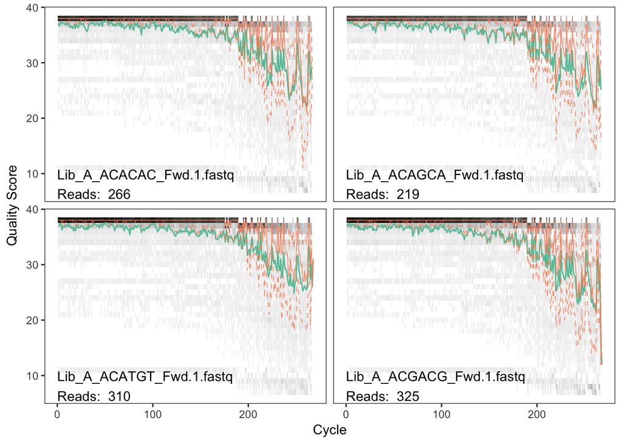

The quality should be similar to that of the Reverse .1 reads

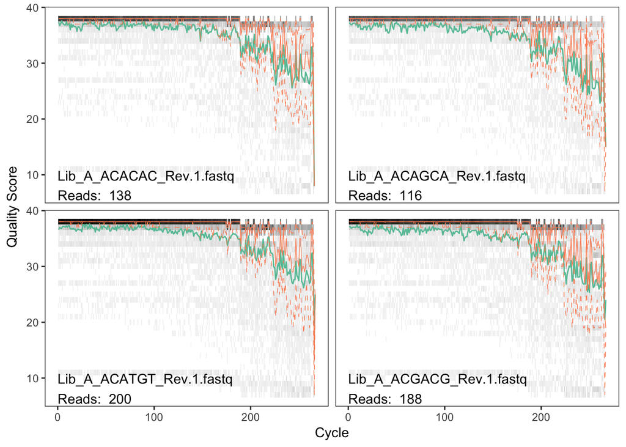

On the other hand, the quality of the .2 reads should decrease earlier

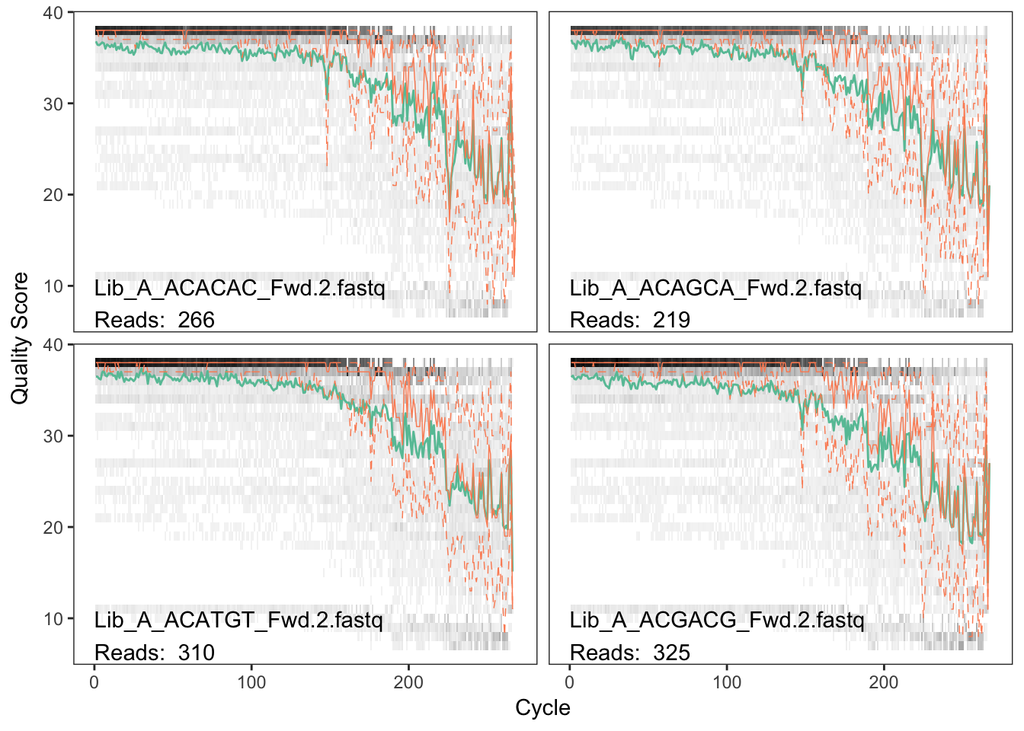

## Now start with the trimming of each read based on the quality we just plotted

```r
filt_path <- file.path(path1, "filtered") # Place filtered files in filtered/ subdirectory
filtF1s <- file.path(filt_path, paste0(good.sample.names, "_F1_filt.fastq.gz"))
filtF2s <- file.path(filt_path, paste0(good.sample.names, "_F2_filt.fastq.gz"))
out <- filterAndTrim(F1sgood, filtF1s, F2sgood, filtF2s, truncLen=c(240,160),
                      maxN=0, maxEE=c(2,2), truncQ=2, rm.phix=TRUE,
                      compress=TRUE, multithread=TRUE) # On Windows set multithread=FALSE
```

```r
out_tibble<-tibble(file=dimnames(out)[[1]], reads.out=out[,2])
```

Now the first crucial step: learning the error rates that would be different for fwd and rev reads

```
## Initializing error rates to maximum possible estimate.
## Sample 1 - 211 reads in 128 unique sequences.
## Sample 2 - 182 reads in 104 unique sequences.
## Sample 3 - 261 reads in 168 unique sequences.
## Sample 4 - 249 reads in 141 unique sequences.
## Sample 5 - 152 reads in 86 unique sequences.
## Sample 6 - 203 reads in 132 unique sequences.
## Sample 7 - 314 reads in 181 unique sequences.
## Sample 8 - 117 reads in 93 unique sequences.
## Sample 9 - 145 reads in 114 unique sequences.
## Sample 10 - 117 reads in 74 unique sequences.
## Sample 11 - 251 reads in 149 unique sequences.
## Sample 12 - 293 reads in 201 unique sequences.
## Sample 13 - 241 reads in 130 unique sequences.
## Sample 14 - 221 reads in 172 unique sequences.
## Sample 15 - 251 reads in 166 unique sequences.
## Sample 16 - 228 reads in 161 unique sequences.
## Sample 17 - 210 reads in 132 unique sequences.
## Sample 18 - 182 reads in 131 unique sequences.
## Sample 19 - 190 reads in 129 unique sequences.
## Sample 20 - 183 reads in 121 unique sequences.
## Sample 21 - 231 reads in 160 unique sequences.
## Sample 22 - 147 reads in 90 unique sequences.
## Sample 23 - 171 reads in 111 unique sequences.
## Sample 24 - 206 reads in 124 unique sequences.
## Sample 25 - 224 reads in 124 unique sequences.
## Sample 26 - 166 reads in 128 unique sequences.
## Sample 27 - 222 reads in 125 unique sequences.
## Sample 28 - 168 reads in 101 unique sequences.
## Sample 29 - 186 reads in 137 unique sequences.
## Sample 30 - 221 reads in 137 unique sequences.
## Sample 31 - 153 reads in 118 unique sequences.
## Sample 32 - 204 reads in 110 unique sequences.
## Sample 33 - 270 reads in 142 unique sequences.
## Sample 34 - 204 reads in 115 unique sequences.
## Sample 35 - 151 reads in 82 unique sequences.
## Sample 36 - 133 reads in 99 unique sequences.
## Sample 37 - 122 reads in 102 unique sequences.
## Sample 38 - 266 reads in 191 unique sequences.
## Sample 39 - 126 reads in 82 unique sequences.
```

[output cut: 43 more lines]

```
## Sample 83 - 172 reads in 102 unique sequences.
## Sample 84 - 184 reads in 129 unique sequences.
## Sample 85 - 160 reads in 97 unique sequences.
## Sample 86 - 265 reads in 152 unique sequences.
## Sample 87 - 169 reads in 110 unique sequences.
## Sample 88 - 134 reads in 75 unique sequences.
## Sample 89 - 266 reads in 177 unique sequences.
## Sample 90 - 177 reads in 119 unique sequences.
## Sample 91 - 273 reads in 155 unique sequences.
## Sample 92 - 191 reads in 128 unique sequences.
## Sample 93 - 260 reads in 150 unique sequences.
##    selfConsist step 2
##    selfConsist step 3
## Convergence after  3  rounds.
## Total reads used:  18320
```

```
## Initializing error rates to maximum possible estimate.
## Sample 1 - 211 reads in 98 unique sequences.
## Sample 2 - 182 reads in 83 unique sequences.
## Sample 3 - 261 reads in 146 unique sequences.
## Sample 4 - 249 reads in 99 unique sequences.
## Sample 5 - 152 reads in 63 unique sequences.
## Sample 6 - 203 reads in 95 unique sequences.
## Sample 7 - 314 reads in 141 unique sequences.
## Sample 8 - 117 reads in 70 unique sequences.
## Sample 9 - 145 reads in 92 unique sequences.
## Sample 10 - 117 reads in 69 unique sequences.
## Sample 11 - 251 reads in 127 unique sequences.
## Sample 12 - 293 reads in 158 unique sequences.
## Sample 13 - 241 reads in 97 unique sequences.
## Sample 14 - 221 reads in 151 unique sequences.
## Sample 15 - 251 reads in 133 unique sequences.
## Sample 16 - 228 reads in 137 unique sequences.
## Sample 17 - 210 reads in 97 unique sequences.
## Sample 18 - 182 reads in 103 unique sequences.
## Sample 19 - 190 reads in 99 unique sequences.
## Sample 20 - 183 reads in 97 unique sequences.
## Sample 21 - 231 reads in 141 unique sequences.
## Sample 22 - 147 reads in 73 unique sequences.
## Sample 23 - 171 reads in 98 unique sequences.
## Sample 24 - 206 reads in 88 unique sequences.
## Sample 25 - 224 reads in 92 unique sequences.
## Sample 26 - 166 reads in 112 unique sequences.
## Sample 27 - 222 reads in 93 unique sequences.
## Sample 28 - 168 reads in 66 unique sequences.
## Sample 29 - 186 reads in 95 unique sequences.
## Sample 30 - 221 reads in 97 unique sequences.
## Sample 31 - 153 reads in 105 unique sequences.
## Sample 32 - 204 reads in 91 unique sequences.
## Sample 33 - 270 reads in 107 unique sequences.
## Sample 34 - 204 reads in 84 unique sequences.
## Sample 35 - 151 reads in 56 unique sequences.
## Sample 36 - 133 reads in 86 unique sequences.
## Sample 37 - 122 reads in 81 unique sequences.
## Sample 38 - 266 reads in 144 unique sequences.
## Sample 39 - 126 reads in 69 unique sequences.
```

[output cut: 44 more lines]

```
## Sample 84 - 184 reads in 110 unique sequences.
## Sample 85 - 160 reads in 74 unique sequences.
## Sample 86 - 265 reads in 113 unique sequences.
## Sample 87 - 169 reads in 93 unique sequences.
## Sample 88 - 134 reads in 54 unique sequences.
## Sample 89 - 266 reads in 140 unique sequences.
## Sample 90 - 177 reads in 109 unique sequences.
## Sample 91 - 273 reads in 132 unique sequences.
## Sample 92 - 191 reads in 108 unique sequences.
## Sample 93 - 260 reads in 149 unique sequences.
##    selfConsist step 2
##    selfConsist step 3
##    selfConsist step 4
## Convergence after  4  rounds.
## Total reads used:  18320
```

Which we can plot now to see the error rates between transitions of each pair of nt

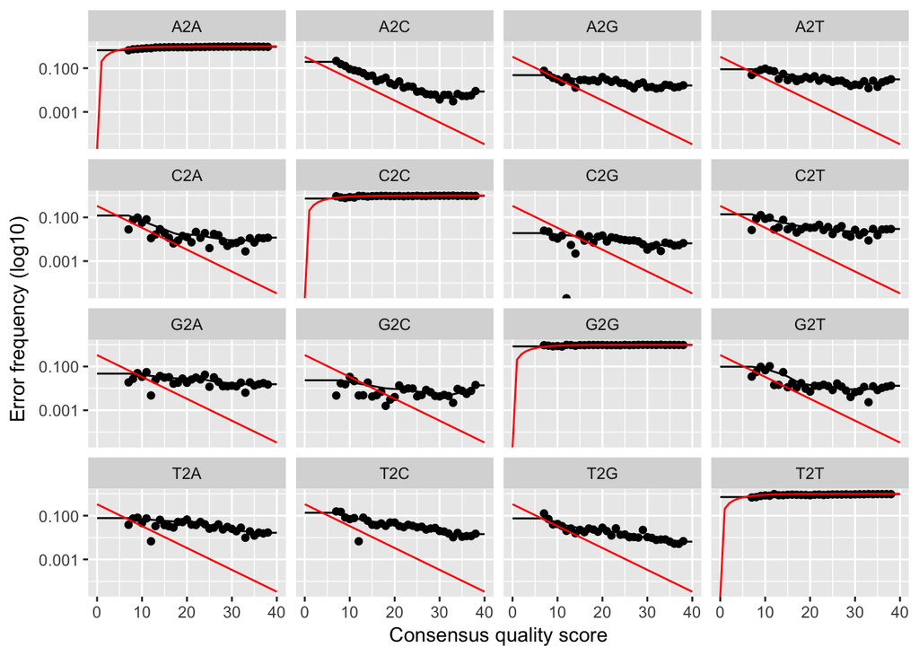

```r
plotErrors(errF1, nominalQ = T)
```

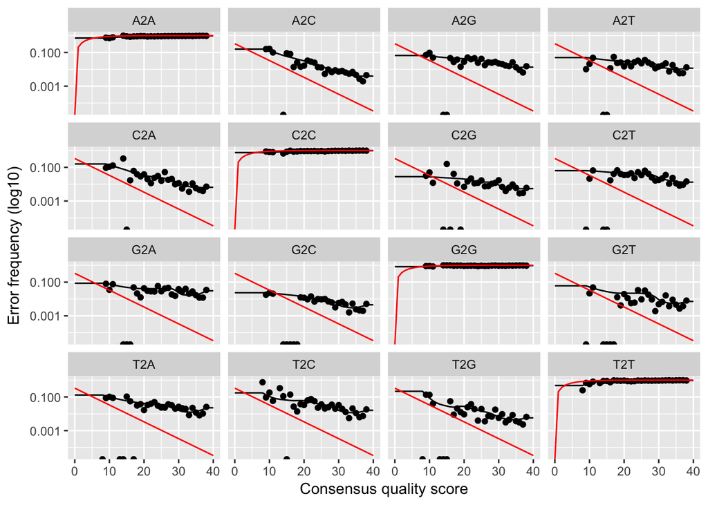

```r
plotErrors(errF2, nominalQ = T)
```

## Now go to the dereplication step

## And finally an inference of the sample composition

```r
dadaFs <- dada(derepFs, err = errF1, multithread = TRUE)
```

```
## Sample 1 - 211 reads in 128 unique sequences.
## Sample 2 - 182 reads in 104 unique sequences.
## Sample 3 - 261 reads in 168 unique sequences.
## Sample 4 - 249 reads in 141 unique sequences.
## Sample 5 - 152 reads in 86 unique sequences.
## Sample 6 - 203 reads in 132 unique sequences.
## Sample 7 - 314 reads in 181 unique sequences.
## Sample 8 - 117 reads in 93 unique sequences.
## Sample 9 - 145 reads in 114 unique sequences.
## Sample 10 - 117 reads in 74 unique sequences.
## Sample 11 - 251 reads in 149 unique sequences.
## Sample 12 - 293 reads in 201 unique sequences.
## Sample 13 - 241 reads in 130 unique sequences.
## Sample 14 - 221 reads in 172 unique sequences.
## Sample 15 - 251 reads in 166 unique sequences.
## Sample 16 - 228 reads in 161 unique sequences.
## Sample 17 - 210 reads in 132 unique sequences.
## Sample 18 - 182 reads in 131 unique sequences.
## Sample 19 - 190 reads in 129 unique sequences.
## Sample 20 - 183 reads in 121 unique sequences.
## Sample 21 - 231 reads in 160 unique sequences.
## Sample 22 - 147 reads in 90 unique sequences.
## Sample 23 - 171 reads in 111 unique sequences.
## Sample 24 - 206 reads in 124 unique sequences.
## Sample 25 - 224 reads in 124 unique sequences.
## Sample 26 - 166 reads in 128 unique sequences.
## Sample 27 - 222 reads in 125 unique sequences.
## Sample 28 - 168 reads in 101 unique sequences.
## Sample 29 - 186 reads in 137 unique sequences.
## Sample 30 - 221 reads in 137 unique sequences.
## Sample 31 - 153 reads in 118 unique sequences.
## Sample 32 - 204 reads in 110 unique sequences.
## Sample 33 - 270 reads in 142 unique sequences.
## Sample 34 - 204 reads in 115 unique sequences.
## Sample 35 - 151 reads in 82 unique sequences.
## Sample 36 - 133 reads in 99 unique sequences.
## Sample 37 - 122 reads in 102 unique sequences.
## Sample 38 - 266 reads in 191 unique sequences.
## Sample 39 - 126 reads in 82 unique sequences.
## Sample 40 - 145 reads in 82 unique sequences.
```

[output cut: 38 more lines]

```
## Sample 79 - 152 reads in 95 unique sequences.
## Sample 80 - 123 reads in 89 unique sequences.
## Sample 81 - 196 reads in 108 unique sequences.
## Sample 82 - 170 reads in 132 unique sequences.
## Sample 83 - 172 reads in 102 unique sequences.
## Sample 84 - 184 reads in 129 unique sequences.
## Sample 85 - 160 reads in 97 unique sequences.
## Sample 86 - 265 reads in 152 unique sequences.
## Sample 87 - 169 reads in 110 unique sequences.
## Sample 88 - 134 reads in 75 unique sequences.
## Sample 89 - 266 reads in 177 unique sequences.
## Sample 90 - 177 reads in 119 unique sequences.
## Sample 91 - 273 reads in 155 unique sequences.
## Sample 92 - 191 reads in 128 unique sequences.
## Sample 93 - 260 reads in 150 unique sequences.
```

```r
dadaRs <- dada(derepRs, err = errF2, multithread = TRUE)
```

```
## Sample 1 - 211 reads in 98 unique sequences.
## Sample 2 - 182 reads in 83 unique sequences.
## Sample 3 - 261 reads in 146 unique sequences.
## Sample 4 - 249 reads in 99 unique sequences.
## Sample 5 - 152 reads in 63 unique sequences.
## Sample 6 - 203 reads in 95 unique sequences.
## Sample 7 - 314 reads in 141 unique sequences.
## Sample 8 - 117 reads in 70 unique sequences.
## Sample 9 - 145 reads in 92 unique sequences.
## Sample 10 - 117 reads in 69 unique sequences.
## Sample 11 - 251 reads in 127 unique sequences.
## Sample 12 - 293 reads in 158 unique sequences.
## Sample 13 - 241 reads in 97 unique sequences.
## Sample 14 - 221 reads in 151 unique sequences.
## Sample 15 - 251 reads in 133 unique sequences.
## Sample 16 - 228 reads in 137 unique sequences.
## Sample 17 - 210 reads in 97 unique sequences.
## Sample 18 - 182 reads in 103 unique sequences.
## Sample 19 - 190 reads in 99 unique sequences.
## Sample 20 - 183 reads in 97 unique sequences.
## Sample 21 - 231 reads in 141 unique sequences.
## Sample 22 - 147 reads in 73 unique sequences.
## Sample 23 - 171 reads in 98 unique sequences.
## Sample 24 - 206 reads in 88 unique sequences.
## Sample 25 - 224 reads in 92 unique sequences.
## Sample 26 - 166 reads in 112 unique sequences.
## Sample 27 - 222 reads in 93 unique sequences.
## Sample 28 - 168 reads in 66 unique sequences.
## Sample 29 - 186 reads in 95 unique sequences.
## Sample 30 - 221 reads in 97 unique sequences.
## Sample 31 - 153 reads in 105 unique sequences.
## Sample 32 - 204 reads in 91 unique sequences.
## Sample 33 - 270 reads in 107 unique sequences.
## Sample 34 - 204 reads in 84 unique sequences.
## Sample 35 - 151 reads in 56 unique sequences.
## Sample 36 - 133 reads in 86 unique sequences.
## Sample 37 - 122 reads in 81 unique sequences.
## Sample 38 - 266 reads in 144 unique sequences.
## Sample 39 - 126 reads in 69 unique sequences.
## Sample 40 - 145 reads in 73 unique sequences.
```

[output cut: 38 more lines]

```
## Sample 79 - 152 reads in 67 unique sequences.
## Sample 80 - 123 reads in 66 unique sequences.
## Sample 81 - 196 reads in 81 unique sequences.
## Sample 82 - 170 reads in 113 unique sequences.
## Sample 83 - 172 reads in 81 unique sequences.
## Sample 84 - 184 reads in 110 unique sequences.
## Sample 85 - 160 reads in 74 unique sequences.
## Sample 86 - 265 reads in 113 unique sequences.
## Sample 87 - 169 reads in 93 unique sequences.
## Sample 88 - 134 reads in 54 unique sequences.
## Sample 89 - 266 reads in 140 unique sequences.
## Sample 90 - 177 reads in 109 unique sequences.
## Sample 91 - 273 reads in 132 unique sequences.
## Sample 92 - 191 reads in 108 unique sequences.
## Sample 93 - 260 reads in 149 unique sequences.
```

## We are ready now to merge reads - using the denoised reads and the derep files

```r
mergersF<-mergePairs(dadaFs, derepFs, dadaRs, derepRs, verbose=T)
```

```
## 193 paired-reads (in 5 unique pairings) successfully merged out of 211 (in 12 pairings) input.
```

```
## 165 paired-reads (in 4 unique pairings) successfully merged out of 182 (in 11 pairings) input.
```

```
## 216 paired-reads (in 13 unique pairings) successfully merged out of 261 (in 25 pairings) input.
```

```
## 242 paired-reads (in 8 unique pairings) successfully merged out of 249 (in 14 pairings) input.
```

```
## 136 paired-reads (in 6 unique pairings) successfully merged out of 152 (in 15 pairings) input.
```

```
## 182 paired-reads (in 9 unique pairings) successfully merged out of 203 (in 18 pairings) input.
```

```
## 280 paired-reads (in 7 unique pairings) successfully merged out of 314 (in 17 pairings) input.
```

```
## 108 paired-reads (in 7 unique pairings) successfully merged out of 117 (in 9 pairings) input.
```

```
## 100 paired-reads (in 6 unique pairings) successfully merged out of 145 (in 11 pairings) input.
```

```
## 92 paired-reads (in 5 unique pairings) successfully merged out of 117 (in 7 pairings) input.
```

```
## 219 paired-reads (in 9 unique pairings) successfully merged out of 251 (in 23 pairings) input.
```

```
## 264 paired-reads (in 6 unique pairings) successfully merged out of 293 (in 13 pairings) input.
```

```
## 235 paired-reads (in 7 unique pairings) successfully merged out of 241 (in 8 pairings) input.
```

```
## 194 paired-reads (in 13 unique pairings) successfully merged out of 221 (in 24 pairings) input.
```

```
## 224 paired-reads (in 9 unique pairings) successfully merged out of 251 (in 21 pairings) input.
```

```
## 199 paired-reads (in 13 unique pairings) successfully merged out of 228 (in 20 pairings) input.
```

```
## 174 paired-reads (in 6 unique pairings) successfully merged out of 210 (in 13 pairings) input.
```

```
## 155 paired-reads (in 9 unique pairings) successfully merged out of 182 (in 15 pairings) input.
```

```
## 168 paired-reads (in 11 unique pairings) successfully merged out of 190 (in 13 pairings) input.
```

```
## 130 paired-reads (in 9 unique pairings) successfully merged out of 183 (in 16 pairings) input.
```

```
## 196 paired-reads (in 10 unique pairings) successfully merged out of 231 (in 21 pairings) input.
```

```
## 128 paired-reads (in 8 unique pairings) successfully merged out of 147 (in 14 pairings) input.
```

```
## 146 paired-reads (in 5 unique pairings) successfully merged out of 171 (in 14 pairings) input.
```

```
## 195 paired-reads (in 8 unique pairings) successfully merged out of 206 (in 14 pairings) input.
```

```
## 208 paired-reads (in 7 unique pairings) successfully merged out of 224 (in 14 pairings) input.
```

```
## 154 paired-reads (in 10 unique pairings) successfully merged out of 166 (in 17 pairings) input.
```

```
## 205 paired-reads (in 6 unique pairings) successfully merged out of 222 (in 15 pairings) input.
```

```
## 159 paired-reads (in 6 unique pairings) successfully merged out of 168 (in 11 pairings) input.
```

```
## 126 paired-reads (in 5 unique pairings) successfully merged out of 186 (in 18 pairings) input.
```

```
## 188 paired-reads (in 6 unique pairings) successfully merged out of 221 (in 19 pairings) input.
```

```
## 114 paired-reads (in 6 unique pairings) successfully merged out of 153 (in 11 pairings) input.
```

```
## 190 paired-reads (in 6 unique pairings) successfully merged out of 204 (in 14 pairings) input.
```

```
## 265 paired-reads (in 9 unique pairings) successfully merged out of 270 (in 13 pairings) input.
```

```
## 189 paired-reads (in 6 unique pairings) successfully merged out of 204 (in 17 pairings) input.
```

```
## 140 paired-reads (in 6 unique pairings) successfully merged out of 151 (in 11 pairings) input.
```

```
## 59 paired-reads (in 3 unique pairings) successfully merged out of 133 (in 5 pairings) input.
```

```
## 80 paired-reads (in 6 unique pairings) successfully merged out of 122 (in 15 pairings) input.
```

```
## 234 paired-reads (in 10 unique pairings) successfully merged out of 266 (in 15 pairings) input.
```

```
## 119 paired-reads (in 4 unique pairings) successfully merged out of 126 (in 7 pairings) input.
```

```
## 144 paired-reads (in 2 unique pairings) successfully merged out of 145 (in 3 pairings) input.
```

```
## 174 paired-reads (in 8 unique pairings) successfully merged out of 181 (in 12 pairings) input.
```

```
## 97 paired-reads (in 6 unique pairings) successfully merged out of 210 (in 13 pairings) input.
```

```
## 226 paired-reads (in 9 unique pairings) successfully merged out of 256 (in 22 pairings) input.
```

```
## 162 paired-reads (in 7 unique pairings) successfully merged out of 178 (in 13 pairings) input.
```

```
## 218 paired-reads (in 8 unique pairings) successfully merged out of 222 (in 12 pairings) input.
```

```
## 130 paired-reads (in 7 unique pairings) successfully merged out of 146 (in 18 pairings) input.
```

```
## 133 paired-reads (in 9 unique pairings) successfully merged out of 236 (in 19 pairings) input.
```

```
## 189 paired-reads (in 8 unique pairings) successfully merged out of 195 (in 14 pairings) input.
```

```
## 197 paired-reads (in 9 unique pairings) successfully merged out of 236 (in 21 pairings) input.
```

```
## 143 paired-reads (in 3 unique pairings) successfully merged out of 149 (in 6 pairings) input.
```

```
## 134 paired-reads (in 6 unique pairings) successfully merged out of 154 (in 10 pairings) input.
```

```
## 163 paired-reads (in 1 unique pairings) successfully merged out of 163 (in 1 pairings) input.
```

```
## 162 paired-reads (in 11 unique pairings) successfully merged out of 211 (in 24 pairings) input.
```

```
## 157 paired-reads (in 8 unique pairings) successfully merged out of 195 (in 16 pairings) input.
```

```
## 97 paired-reads (in 7 unique pairings) successfully merged out of 163 (in 15 pairings) input.
```

```
## 181 paired-reads (in 7 unique pairings) successfully merged out of 200 (in 15 pairings) input.
```

```
## 124 paired-reads (in 8 unique pairings) successfully merged out of 150 (in 15 pairings) input.
```

```
## 325 paired-reads (in 11 unique pairings) successfully merged out of 347 (in 23 pairings) input.
```

```
## 104 paired-reads (in 7 unique pairings) successfully merged out of 112 (in 11 pairings) input.
```

```
## 108 paired-reads (in 5 unique pairings) successfully merged out of 141 (in 11 pairings) input.
```

```
## 86 paired-reads (in 1 unique pairings) successfully merged out of 96 (in 2 pairings) input.
```

```
## 116 paired-reads (in 6 unique pairings) successfully merged out of 146 (in 14 pairings) input.
```

```
## 81 paired-reads (in 5 unique pairings) successfully merged out of 104 (in 9 pairings) input.
```

```
## 530 paired-reads (in 19 unique pairings) successfully merged out of 613 (in 49 pairings) input.
```

```
## 128 paired-reads (in 8 unique pairings) successfully merged out of 157 (in 15 pairings) input.
```

```
## 152 paired-reads (in 7 unique pairings) successfully merged out of 176 (in 19 pairings) input.
```

```
## 166 paired-reads (in 5 unique pairings) successfully merged out of 173 (in 8 pairings) input.
```

```
## 101 paired-reads (in 4 unique pairings) successfully merged out of 213 (in 11 pairings) input.
```

```
## 238 paired-reads (in 5 unique pairings) successfully merged out of 250 (in 7 pairings) input.
```

```
## 123 paired-reads (in 7 unique pairings) successfully merged out of 129 (in 11 pairings) input.
```

```
## 209 paired-reads (in 5 unique pairings) successfully merged out of 226 (in 12 pairings) input.
```

```
## 197 paired-reads (in 9 unique pairings) successfully merged out of 250 (in 14 pairings) input.
```

```
## 121 paired-reads (in 5 unique pairings) successfully merged out of 127 (in 8 pairings) input.
```

```
## 161 paired-reads (in 4 unique pairings) successfully merged out of 172 (in 8 pairings) input.
```

```
## 303 paired-reads (in 9 unique pairings) successfully merged out of 362 (in 23 pairings) input.
```

```
## 38 paired-reads (in 4 unique pairings) successfully merged out of 120 (in 13 pairings) input.
```

```
## 168 paired-reads (in 7 unique pairings) successfully merged out of 226 (in 18 pairings) input.
```

```
## 101 paired-reads (in 6 unique pairings) successfully merged out of 126 (in 11 pairings) input.
```

```
## 145 paired-reads (in 3 unique pairings) successfully merged out of 152 (in 7 pairings) input.
```

```
## 106 paired-reads (in 6 unique pairings) successfully merged out of 123 (in 11 pairings) input.
```

```
## 181 paired-reads (in 6 unique pairings) successfully merged out of 196 (in 11 pairings) input.
```

```
## 138 paired-reads (in 4 unique pairings) successfully merged out of 170 (in 8 pairings) input.
```

```
## 153 paired-reads (in 5 unique pairings) successfully merged out of 172 (in 12 pairings) input.
```

```
## 140 paired-reads (in 7 unique pairings) successfully merged out of 184 (in 18 pairings) input.
```

```
## 145 paired-reads (in 5 unique pairings) successfully merged out of 160 (in 12 pairings) input.
```

```
## 256 paired-reads (in 10 unique pairings) successfully merged out of 265 (in 17 pairings) input.
```

```
## 129 paired-reads (in 6 unique pairings) successfully merged out of 169 (in 16 pairings) input.
```

```
## 121 paired-reads (in 3 unique pairings) successfully merged out of 134 (in 8 pairings) input.
```

```
## 251 paired-reads (in 11 unique pairings) successfully merged out of 266 (in 21 pairings) input.
```

```
## 134 paired-reads (in 9 unique pairings) successfully merged out of 177 (in 16 pairings) input.
```

```
## 250 paired-reads (in 6 unique pairings) successfully merged out of 273 (in 21 pairings) input.
```

```
## 150 paired-reads (in 5 unique pairings) successfully merged out of 191 (in 12 pairings) input.
```

```
## 243 paired-reads (in 11 unique pairings) successfully merged out of 260 (in 20 pairings) input.
```

```r
head(mergersF[[1]])
```

```
##                                                                                                                                                                                                                                                                                                          …
## 1 TTTAAGTGGAATCCTAGCACATTCTGGAGGATCTGTAGATCTTGCAATTTTTAGTTTACA…
## 2 TCTAGCAGGGATTCAAGCTCATTCAGGAGGTTCTGTTGATTTAGCAATTTTCTCTCTTCA…
## 3 TCTTTCAAGTGGAACTTCTCATTCAGGTGGAGCTGTTGATTTAGCTATTTTCAGTTTACA…
## 4 ACTTTCAAGTGGTACGTCTCACTCTGGTGGAGCTGTTGATCTAGCTATCTTTAGTTTACA…
## 5 ACTAAGTCATATTACTAGTCACTCAGGAGGTGCTGTAGATTTAGCTATTTTTAGTTTACA…
##   abundance forward reverse nmatch nmismatch nindel prefer accept
## 1       100       1       1     87         0      0      2   TRUE
## 2        43       2       2     87         0      0      2   TRUE
## 3        22       5       4     87         0      0      2   TRUE
## 4        18       3       3     87         0      0      2   TRUE
## 5        10       4       5     87         0      0      2   TRUE
```

## And we can now construct the sequence abundance table

```r
seqtab <- makeSequenceTable(mergersF)
```

```
## The sequences being tabled vary in length.
```

```r
dim(seqtab)
```

```
## [1] 93 86
```

```r
table(nchar(getSequences(seqtab)))
```

```
##
## 304 310 311 312 313 316 319 349 355
##   3   1   2   1  69   3   5   1   1
```

## Now get rid of the chimeras

```r
seqtab.nochim <- removeBimeraDenovo(seqtab, method="consensus", multithread=TRUE, verbose=TRUE)
dim(seqtab.nochim)
```

```
## [1] 93 86
```

##Track the fate of all reads

```r
getN <- function(x) sum(getUniques(x))
track <- cbind(out, sapply(dadaFs, getN), sapply(mergersF, getN), rowSums(seqtab), rowSums(seqtab.nochim))
# If processing a single sample, remove the sapply calls: e.g. replace sapply(dadaFs, getN) with getN(dadaFs)
colnames(track) <- c("input", "filtered", "denoised", "merged", "tabled", "nonchim")
rownames(track) <- good.sample.names
head(track)
```

```
##              input filtered denoised merged tabled nonchim
## Lib_A_ACACAC   266      211      211    193    193     193
## Lib_A_ACAGCA   219      182      182    165    165     165
## Lib_A_ACATGT   310      261      261    216    216     216
## Lib_A_ACGACG   325      249      249    242    242     242
## Lib_A_ATATCG   176      152      152    136    136     136
## Lib_A_CGACGC   264      203      203    182    182     182
```